# Project 1: Urban Ministries of Durham

YuxiaoYao

9/25/2019

# Background

Non-profit Urban Ministries of Durham (UMD) connects poor and homeless neighbors to food, shelter and a future. They connect with the community to end homelessness and fight poverty by offering food, shelter and a future to neighbors in need. Here is the official website of UMD: http://www.umdurham.org/.

# Dataset

- Date Date service was provided
- Client File Number Family identifier (individual or family)
- Client File Merge Separate files were created for one family and merged later
- Bus Tickets (Number of): Service discontinued
- Notes of Service
- Food Provided for: Number of people in the family for which food was provided
- Food Pounds: Number of pounds of food that each individual or family received when shopping at UMD food pantry
- Clothing Items: Number of clothing items received per family or individual
- Diapers: Number of packs of diapers received (individuals/families are given 2 packs of diapers per child, and packs contain 22 diapers on average)
- School Kits
- Hygiene Kits: Number of kits received per individual or family. Kits contain soap, shampoo, conditioner, lotion, deodorant, a toothbrush, toothpaste, a washcloth, a disposable razor, and a bottle of shaving cream.
- Financial Support: Money provided. Service discontinued

# Questions

Since the main purpose of the project is to help UMD with desicion making, here are some of questions I am interested in. Firstly, the number of clients plays an important role because it is related to the scale of services provided by UMD. Also, the changes of client number shows how UMD developed over years. Secondly, I would like to focus on seasonalities of the services, especially food and clothing services. Assumingly, clients need more food and clothing items in winter than summer. The results can provide UMD with some suggestions on food and clothes collecting and preserving decisions. Then I am interested in clients who have babies, so I would like to see the correlations between diapers and clothing items/food. So here are four questions I would like to analyze:

- How many clients were served by UMD between 1998 and 2018? Are there any trends?
- How many food pounds are provided each month from 2008 to 2017? Is there a seasonality?
- How many clothing items are provided each month from 2008 to 2017? Is there a seasonality?
- Are there any correlations between diapers and clothing items/food?

# Data Preparation

For data preparation, I convert the data type of “Date” into date type. Then I changed variable names to avoid space in them for convinence. Also, I limited the time scale using filter to avoid incomplete data in this year (2019).

```r
library(tidyverse)

raw = read_tsv("https://raw.githubusercontent.com/datasci611/bios611-projects-fall-2019-YaoYuxiao/master/project_1/data/UMD_Services_Provided_20190719.tsv")

# convert the data type into Date
raw$Date<-as.Date(raw$Date,format="%m/%d/%Y")
#preparation: rename variables and filter by time
data=raw %>%
  rename('id'='Client File Number','Food'='Food Pounds','Clothing'='Clothing Items',
         'Schoolkits'='School Kits','Money'='Financial Support')%>%
  filter(Date>="1998-01-01" & Date<="2018-12-31")
data
```

```
## # A tibble: 76,550 x 18
##    Date          id `Client File Me~ `Bus Tickets (N~ `Notes of Servi~
##    <date>     <dbl>            <dbl>            <dbl> <chr>
##  1 2009-01-22   212                0               NA <NA>
##  2 2009-01-29   738                0               NA <NA>
##  3 2009-01-20  3455                0               NA <NA>
##  4 2002-11-26  1804            21804               NA <NA>
##  5 2002-12-02  1806            21806               NA <NA>
##  6 2002-10-10  1614            21614               NA financial refer~
##  7 2002-09-26  1758            21758               NA Financial Refer~
##  8 2008-02-19  1814                0               NA <NA>
##  9 2002-10-10   522            20522               NA greyhound ticket
## 10 2002-09-04  1356            21356               10 <NA>
## # ... with 76,540 more rows, and 13 more variables: `Food Provided
## #   for` <dbl>, Food <dbl>, Clothing <dbl>, Diapers <dbl>,
## #   Schoolkits <dbl>, `Hygiene Kits` <dbl>, Referrals <chr>, Money <dbl>,
## #   `Type of Bill Paid` <chr>, `Payer of Support` <chr>, Field1 <lgl>,
## #   Field2 <lgl>, Field3 <lgl>
```

# Analysis

## Introduction

### Question 1: How many clients were served by UMD between 1998 and 2018? Are there any trends?

```r
# general statistics: average, number label, lines ,smoothing,why(interpretation)
#problem1
# prepare data for p1
client= data %>%
  select(Date, id)%>%
  drop_na() %>%
 distinct(id, .keep_all = TRUE)%>%
  arrange(Date)

client_yearly=client %>%
  separate(Date, sep = "-", into = c("Year", "Month", "Day"))%>%
  group_by(Year) %>%
  summarise(client_sum=n())

client_yearly
```

```
## # A tibble: 21 x 2
##    Year  client_sum
##    <chr>      <int>
##  1 1998          16
##  2 1999         140
##  3 2000          85
##  4 2001         473
##  5 2002         955
##  6 2003         799
##  7 2004         667
##  8 2005         616
##  9 2006         676
## 10 2007         685
## # ... with 11 more rows
```

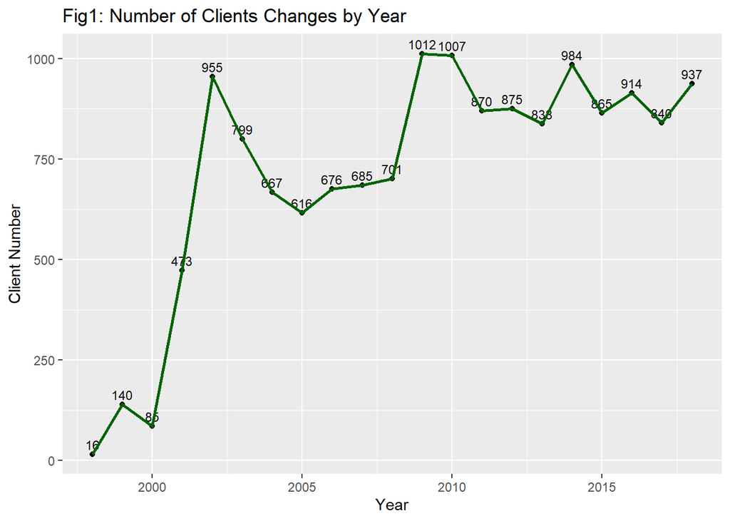

```r
# plot the data
# TODO set breaks for x axis
ggplot(client_yearly,aes(as.numeric(Year),client_sum))+
  geom_point()+
  geom_text(aes(label=client_sum),vjust=-0.5,size=3)+
  geom_line(size=1,color='darkgreen') +
  labs(x="Year",y="Client Number",title = "Fig1: Number of Clients Changes by Year")
```

## Seasonality Analysis

### Question 2: How many food pounds are provided each month from 2008 to 2017? Is there a seasonality?

Assumingly, clients need more food in winter than summer. This could be helpful for UMD to get prepared by knowing how many food pounds should be collected each month. In this part, I limited the time from 2008 to 2017 to avoid abnormal data in June, 2018. This c would not affect the seasonality we want to find.

```r
food_group= data %>%
  select(Date, 'Food')%>%
  drop_na() %>%
  filter(Date>="2008-01-01"&Date<="2017-12-31")%>%
  separate(Date, sep = "-", into = c("Year", "Month", "Day"))%>%
  group_by(Year,Month)%>%
  summarise(num=n(),mean=mean(Food))%>%
  mutate(sum=num*mean)%>%
  arrange(desc(Year))
food_group
```

```
## # A tibble: 120 x 5
## # Groups:   Year [10]
##    Year  Month   num  mean   sum
##    <chr> <chr> <int> <dbl> <dbl>
##  1 2017  01      438  24.8 10875
##  2 2017  02      387  25.2  9770
##  3 2017  03      453  23.9 10845
##  4 2017  04      403  22.2  8935
##  5 2017  05      483  23.0 11132
##  6 2017  06      491  23.8 11695
##  7 2017  07      421  22.9  9635
##  8 2017  08      500  24.6 12287
##  9 2017  09      442  22.7 10049
## 10 2017  10      544  20.8 11340
## # ... with 110 more rows
```

```r
food_group_by_month=food_group%>%
  group_by(Month)%>%
  summarise(num_monthly=mean(num)*12)%>%
  arrange(desc(Month))
food_group_by_month
```

```
## # A tibble: 12 x 2
##    Month num_monthly
##    <chr>       <dbl>
##  1 12          5222.
##  2 11          5312.
##  3 10          5593.
##  4 09          5210.
##  5 08          5213.
##  6 07          5113.
##  7 06          5318.
##  8 05          4897.
##  9 04          5066.
## 10 03          5189.
## 11 02          4488
## 12 01          5077.
```

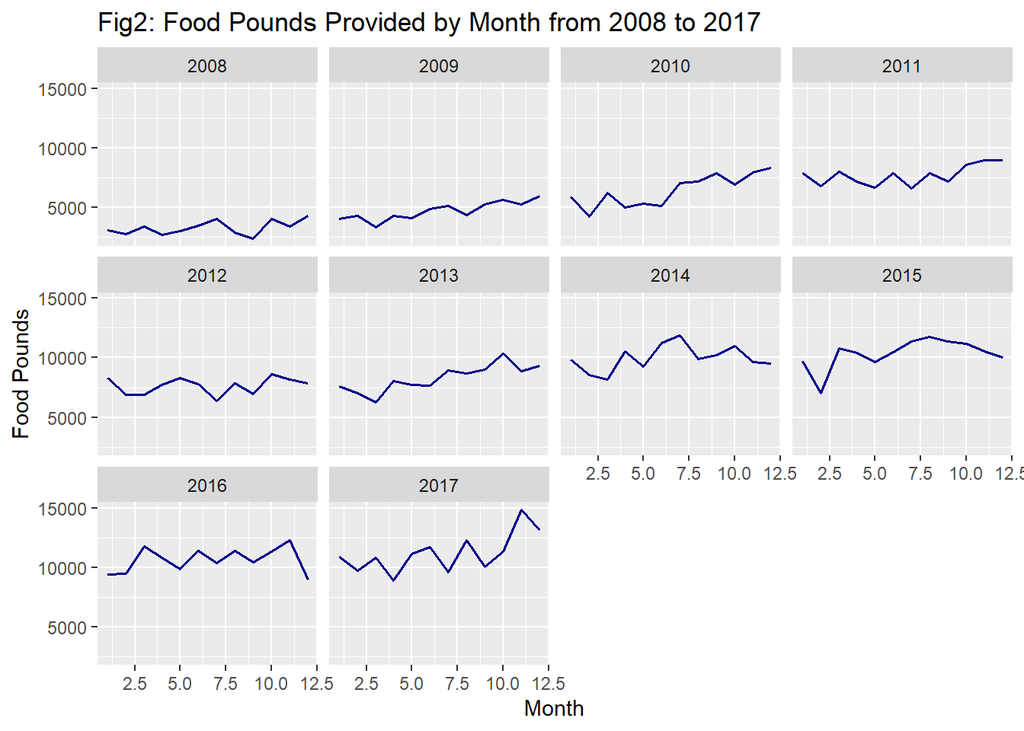

```r
ggplot(food_group,aes(as.numeric(Month),sum))+
 # geom_bar(mapping = aes(x = Month, y = sum), stat = "identity") +
  geom_line(size=0.7,color='darkblue')+
  labs(x="Month",y="Food Pounds",title = "Fig2: Food Pounds Provided by Month from 2008 to 2017")+
  facet_wrap(vars(Year)) #TODO change to 3*3
```

[figure not shown]

```r
# TODO set breaks for x axis

ggplot(food_group_by_month,aes(as.numeric(Month),num_monthly))+
  geom_line(size=1,color='darkblue')+
  geom_text(aes(label=num_monthly),vjust=-0.5,size=3)+
  scale_x_continuous(breaks = c(1,2,3,4,5,6,7,8,9,10,11,12))+
  labs(x="Month",y="Food Pounds",title = "Fig3: Sum of Food Pounds Provided by Month from 2008 to 2017")
```

### Question 3: How many clothing items are provided each month from 2008 to 2017? Is there a seasonality?

```r
clothing_group= data %>%
  select(Date, 'Clothing')%>%
  drop_na() %>%
  filter(Date>="2008-01-01"&Date<="2017-12-31")%>% # focus on ten years(2008-2017)，because of abnormal data in June 2018
  separate(Date, sep = "-", into = c("Year", "Month", "Day"))%>%
  group_by(Year,Month)%>%
  summarise(num=n(),mean=mean(Clothing))%>%
  mutate(sum=num*mean)%>%
  arrange(desc(Year))
clothing_group
```

```
## # A tibble: 120 x 5
## # Groups:   Year [10]
##    Year  Month   num  mean   sum
##    <chr> <chr> <int> <dbl> <dbl>
##  1 2017  01      425  9.45 4017.
##  2 2017  02      377  8.76 3302
##  3 2017  03      445  8.65 3850
##  4 2017  04      398  8.03 3197.
##  5 2017  05      479  8.20 3928
##  6 2017  06      484  8.62 4173
##  7 2017  07      417  8.01 3340
##  8 2017  08      490  7.91 3877
##  9 2017  09      434  6.74 2925
## 10 2017  10      534  6.76 3609
## # ... with 110 more rows
```

```r
clothing_group_by_month=clothing_group%>%
  group_by(Month)%>%
  summarise(num_monthly=mean(num)*12)%>%
  arrange(desc(Month))
clothing_group_by_month
```

```
## # A tibble: 12 x 2
##    Month num_monthly
##    <chr>       <dbl>
##  1 12          4982.
##  2 11          4999.
##  3 10          5287.
##  4 09          4886.
##  5 08          4922.
##  6 07          4716
##  7 06          4991.
##  8 05          4591.
##  9 04          4771.
## 10 03          4829.
## 11 02          4214.
## 12 01          4738.
```

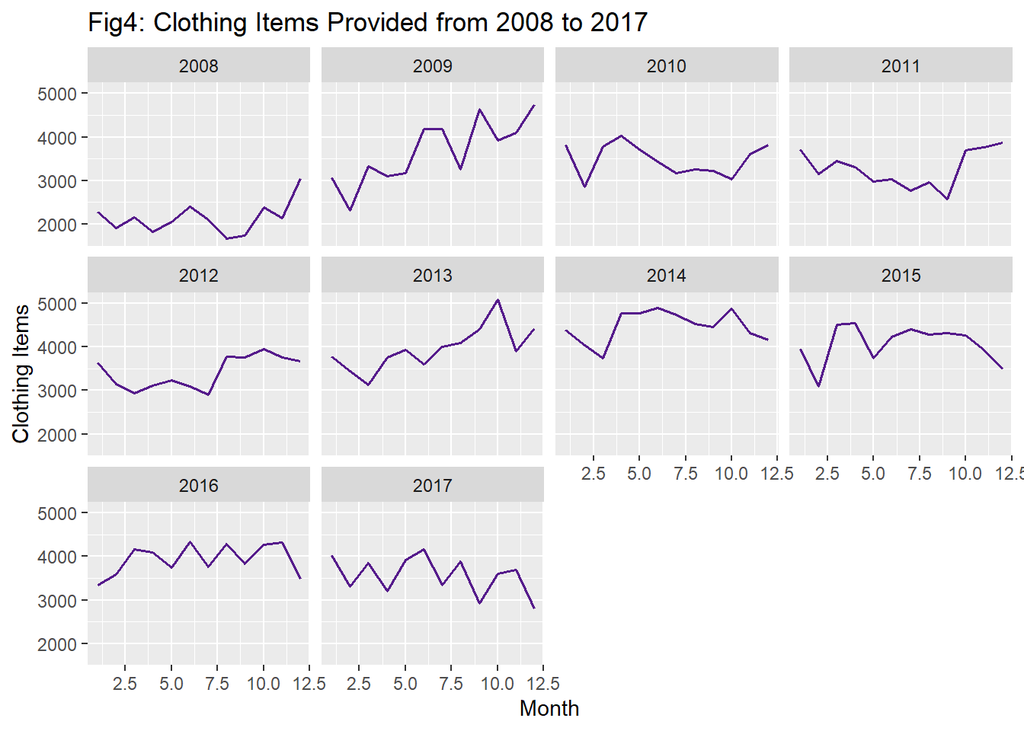

```r
ggplot(clothing_group,aes(as.numeric(Month),sum))+
  # geom_bar(mapping = aes(x = Month, y = sum), stat = "identity") +
  geom_line(size=0.7,color='purple4')+
  labs(x="Month",y="Clothing Items",title = "Fig4: Clothing Items Provided from 2008 to 2017")+
  facet_wrap(vars(Year)) #TODO change to 3*3
```

[figure not shown]

```r
# TODO set breaks for x axis
ggplot(clothing_group_by_month,aes(as.numeric(Month),num_monthly))+
  geom_line(size=1,color='purple4')+
  geom_text(aes(label=num_monthly),vjust=-0.5,size=3)+
  scale_x_continuous(breaks = c(1,2,3,4,5,6,7,8,9,10,11,12))+
  labs(x="Month",y="Food Pounds",title = "Fig5: Sum of Clothing Items Provided by Month from 2008 to 2017")
```

## Correlation Analysis

### Question4: Are there any correlations between diapers and clothing items/food?

```r
# -----------diapers and clothing items----------
corr_data=data%>%
  select(Date,Diapers,Clothing)%>%
  drop_na()%>%
  arrange(desc(Diapers))
# replace NA with 0
# corr_data[is.na(corr_data)]<-0
corr_data
```

```
## # A tibble: 695 x 3
##    Date       Diapers Clothing
##    <date>       <dbl>    <dbl>
##  1 2018-01-26    5303        6
##  2 2014-04-30     156        1
##  3 2013-12-02      60        7
##  4 2010-07-06      60        7
##  5 2015-06-16      60        7
##  6 2017-06-19      50        6
##  7 2017-06-19      50        6
##  8 2015-09-15      45        5
##  9 2005-09-13      36        6
## 10 2015-04-28      30        7
## # ... with 685 more rows
```

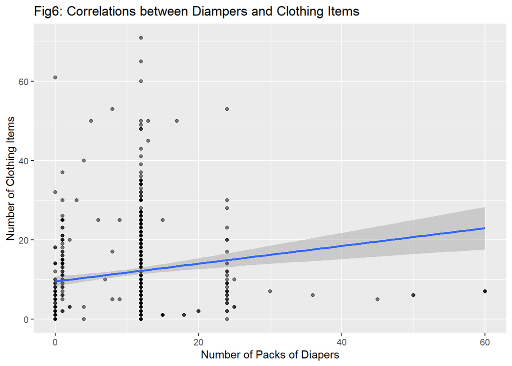

```r
  ggplot(corr_data,aes(Diapers,Clothing))+
    geom_point(alpha=0.5)+
    geom_smooth(method = "lm")+
    scale_x_continuous(limits=c(0,60))+ # set limits to avoid two abnormal data
  labs(x="Number of Packs of Diapers",y="Number of Clothing Items",title="Fig6: Correlations between Diampers and Clothing Items")
```

```r
  # -----------diapers and food----------


corr_data2=data%>%
  select(Date,Diapers,Food)%>%
  drop_na()%>%
  arrange(desc(Diapers))
# replace NA with 0
# corr_data[is.na(corr_data)]<-0
corr_data2
```

```
## # A tibble: 564 x 3
##    Date       Diapers  Food
##    <date>       <dbl> <dbl>
##  1 2018-01-26    5303     0
##  2 2014-04-30     156     0
##  3 2013-12-02      60     0
##  4 2010-07-06      60     0
##  5 2015-06-16      60     0
##  6 2017-06-19      50     0
##  7 2017-06-19      50     0
##  8 2015-09-15      45     0
##  9 2015-04-28      30     0
## 10 2009-03-23      25     1
## # ... with 554 more rows
```

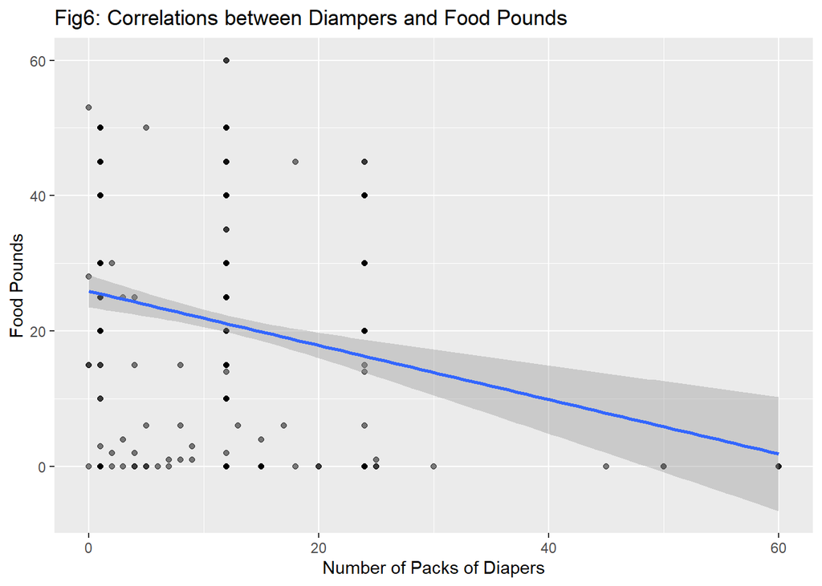

```r
  ggplot(corr_data2,aes(Diapers,Food))+
    geom_point(alpha=0.5)+
    geom_smooth(method = "lm")+
    scale_x_continuous(limits=c(0,60))+ # set limits to avoid two abnormal data
  labs(x="Number of Packs of Diapers",y="Food Pounds",title="Fig6: Correlations between Diampers and Food Pounds")
```

We can see that in clients who need more diapers also need more clothes, but need less food. Also, the number of diapers seems more likely to be 12 or 24 than other random numbers. This might related to the bigger pack of diapers. When we look closely to clients who have babies, we can guess that more babies a family has, more clothing items they need. However, babies do not mean more food, on the contrary, they need less food.

# Conclusions and Discussions

## Limitations

- For question2 and question3, we assume that food and clothing items are provided to feed the need of clients without limitations. However, the services might be affected by other factors. As far as I know, some food and clothes come from neighborhood donation, which may lead to sources problems. Under this condition, food and clothes that are provided to clients cannot represent needs.
- For question4, the underline assumpssion is that more clients who need more diapers have more babies. Although it seems reasonable, it does not have to be the truth.

## Future works

In the presentation, the social workers said they are particularly interested in which clients they can help make a permanent transition to self-sufficiency, and which clients continue to need help. In this context, I would like to find some patterns and differences between different types of clients. For instance, after shrinking the size of the variables through PCA, we can perform a unsupervised cluster analysis to find various types of clients and compare them in terms of mean, variance, kurtosis, and skewness (e.g., parametric methods) and general shape of distribution (e.g., nonparametric methods), based off of the principle components.

- In this regard, it would meaningful to look closely at client duration of assistance.  
  client.duration<- data %>%  
  group_by(`Client File Number`) %>%  
  summarize(Duration=difftime(max(Date),min(Date)))
- We can divide clients to a group of people who received assistance only 1 time and the other who received assistance multiple times.  
  client.assistance <-data %>%  
  group_by(`Client File Number`) %>%  
  summarize(First=min(Date),Last=max(Date)) %>%  
  filter(First==Last)